# Visualization Exercises Part 1

This is the first of several exercise pages on visualization using [Matplotlib](http://matplotlib.org/index.html) that were prepared for use in the course ITSE 1302 at Austin Community College.

These exercise pages were prepared using Jupyter Notebook. They will be delivered to students as HTML downloads. However, students in this course are not expected to know how to create Jupyter Notebooks, but will learn how to use that tool in a later course.

A variety of programming examples are provided in these exercise pages. These examples illustrate everything that you need to know to complete the assignments in this course. However, to make your educational experience more complete, it is recommended that you also study various online resources, such as [https://lectures.scientific-python.org/).

As mentioned above, a variety of programming examples are provided in these exercise pages. In order to make it possible to copy the code for the examples into a Python script and run them under the stand-alone Python interpreter, with the exception of the import statements and utility functions, if any, most of the code in these exercise pages was written in such a way that it can stand alone and run independently of any code that was written earlier in the notebook. Therefore, students should not need to know how to create Jypyter Notebooks to make effective use of these programming examples.

To run a section of Python code under the Python interpreter,

- Copy the import statements into your Python source code editor.
- Copy the utility functions, if any, into the same Python source code file.
- Copy the Python code of interest into the same Python source code file.
- Execute the Python code under your Python version 3+ interpreter.

Note, you must have installed a Python version 3+ distribution that inludes matplotlib, numpy, scipy, etc.

This exercise page concentrates on the different ways that you can arrange multiple plots in a single output image. In order to understand some of the code used in these examples, (such as **axes** for example) you will need to study **Visualization Exercises Part 2** in parallel with your study of this page.

## Import required libraries

```python
import numpy as np
import matplotlib.pyplot as plt
```

## Arranging plots in a figure

Being able to present the results of a Data Science project in text, tables, graphs, and plots in such a way as to [clearly communicate](http://journals.plos.org/ploscompbiol/article?id=10.1371/journal.pcbi.1003833) those results to a reader is a very important capability. Often this will entail the need to combine plots, perhaps in the manner shown in this demonstration from the [Thumbnail Gallery](http://matplotlib.org/examples/statistics/histogram_demo_multihist.html).

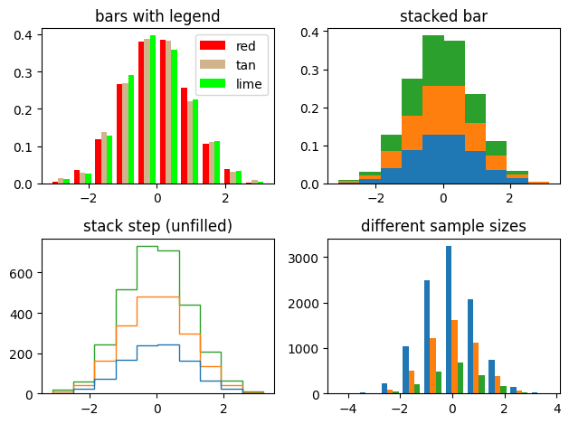

```python
np.random.seed(0)

n_bins = 10
x = np.random.randn(1000, 3)

fig, axes = plt.subplots(nrows=2, ncols=2)
ax0, ax1, ax2, ax3 = axes.flatten()

colors = ['red', 'tan', 'lime']
ax0.hist(x, n_bins, density=True, histtype='bar', color=colors, label=colors)
ax0.legend(prop={'size': 10})
ax0.set_title('bars with legend')

ax1.hist(x, n_bins, density=True, histtype='bar', stacked=True)
ax1.set_title('stacked bar')

ax2.hist(x, n_bins, histtype='step', stacked=True, fill=False)
ax2.set_title('stack step (unfilled)')

# Make a multiple-histogram of data-sets with different length.
x_multi = [np.random.randn(n) for n in [10000, 5000, 2000]]
ax3.hist(x_multi, n_bins, histtype='bar')
ax3.set_title('different sample sizes')

fig.tight_layout()
plt.savefig("VisualizationPart01.zzz.png")
plt.show()
```

## **Description of the image shown above, VisualizationPart01.01.png**

### Type of Image

This is a four‑panel figure containing histogram plots arranged in a 2×2 grid.

### Overall Summary

The figure demonstrates several different ways to display histograms within a single combined layout. Each subplot presents a variation in histogram style, allowing the viewer to compare visual approaches for representing distributions when multiple datasets or stylistic choices are involved.

### Detailed Description

The figure contains four subplots arranged in two rows and two columns.

- **Top‑left subplot:** Three overlaid histograms appear in red, tan, and lime colors. A legend on the right identifies the colors. The subplot title reads “bars with legend.”
- **Top‑right subplot:** A stacked histogram is shown, with three layers in blue, orange, and green. The subplot title reads “stacked bar.”
- **Bottom‑left subplot:** Three unfilled step‑style histograms are displayed in blue, orange, and green. The subplot title reads “stack step (unfilled).”
- **Bottom‑right subplot:** Three overlaid histograms with different sample sizes are shown in blue, orange, and green. The subplot title reads “different sample sizes.”

All four subplots share a similar visual structure, with each demonstrating a distinct histogram style or configuration.

### Purpose of the Image

The purpose of this figure is to illustrate how multiple plots can be arranged within a single figure to communicate results clearly and efficiently. In the context of arranging plots in a Data Science project, this example shows how different histogram styles can be combined to support comparison and interpretation. It also reinforces the importance of presenting results in a way that is visually organized and easy for readers to understand.

### Arrangement can be complex

As you will learn in the document titled **Visualization Exercises Part 2**, when all you need is a single plot, the syntax can be very simple and straightforward. However, when you need to combine two or more plots in the same figure, that can become one of the most complex aspects of using matplotlib.

We will address some of that complexity in the programming examples that follow.

#### What is a figure?

You learned how to quickly create line plots in earlier exercise pages. However, those pages ignored some big-picture issues that you need to know about. Arranging plots in a Figure is one of those big-picture issues. A **Figure** can be thought of as the container for one or more plots or subplots.

If you don't explicitly create a figure when you create a plot, one is automatically created for you. This is evidenced by the following code that doesn't explicitly create a figure. The call to the **plt.gcf** method returns a reference to the current figure, presumeably displaying the dimensions of the figure in pixels.

The code also calls the **savefig** method causing the current figure to be written into an output image file.

```
Figure(640x480)
```

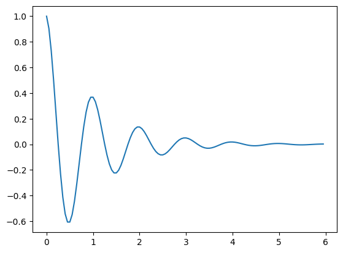

```python
t = np.arange(0, 6.0, 0.05)
plt.plot(t, np.exp(-t) * np.cos(2*np.pi*t))
print(plt.gcf())#Get a reference to the current figure.

plt.savefig("VisualizationPart01.zzz.png")
plt.show()
```

## **Description of the image shown above, VisualizationPart01.02.png**

### Type of Image

This is a single line plot showing a damped oscillatory function.

### Overall Summary

The image displays a curve that begins near a value of 1 and oscillates while gradually decreasing in amplitude as it moves from left to right. The plot illustrates how a function can exhibit repeated peaks and valleys while simultaneously decaying toward zero.

### Detailed Description

The plot shows a smooth line that starts at a high positive value near the left edge of the figure. As the curve progresses to the right, it oscillates above and below the horizontal axis, with each successive oscillation becoming smaller in height. The amplitude decreases steadily, giving the appearance of a wave that is losing energy over time. The horizontal axis runs from 0 to approximately 6, and the vertical axis spans from about –0.6 to 1.0. No labels, titles, or legends are present in the image.

### Purpose of the Image

The purpose of this image is to support the discussion about arranging plots within a figure. It provides a simple example of a single plot that can be displayed on its own or combined with other plots in a more complex figure. In the context of learning how matplotlib handles figures and subplots, this example helps illustrate the distinction between an individual plot and the larger figure that contains it.

#### Different ways to create an arrangement

One of the reasons that arranging subplots in a figure can be complex is because there are different ways to create an arrangement and you need to keep the different ways separated in your mind.

The following code samples show several different ways to create a figure having two rows and three columns of subplots.

##### Call plt.subplots

The next four code samples all call the method named matplotlib.pyplot.subplots to create a figure with two rows and three columns of subplots. (Note the plural spelling of **subplots** in the method name. This will become important later.)

The difference in these code samples is in how they handle the return values.

According to the documentation, the **subplots** method returns a tuple containing a **Figure** object and either an **Axes** object or an array of **Axes** objects depending on whether one or more than one subplot was created.

The first returned value is a reference to the **Figure** object. This reference is used to set the *facecolor* of the figure to gray.

The print statements shows that in this case (2 rows by 3 columns), the second returned value is an array of type numpy.ndarray where *ndarray* stands for n-dimensional array with zero-based indexing.

The code that popluates each of the axes objects with plot data treats the array in a straightforward manner, accessing each element in the array by the row and column index (axes[0,2] for example).

```python
fig,axes = plt.subplots(nrows=2,ncols=3)
#The above statement can also be written as follows:
#fig,axes = plt.subplots(2,3)
fig.set_facecolor('0.75')
print("type of fig =",type(fig))
print("type of axes =",type(axes))
print("type of axes[0,0] =",type(axes[0,0]))

t = np.arange(0, 6.0, 0.05)
axes[0,0].plot(t, np.exp(-t) * np.cos(1*np.pi*t))
axes[0,1].plot(t, np.exp(-t) * np.cos(2*np.pi*t))
axes[0,2].plot(t, np.exp(-t) * np.cos(3*np.pi*t))
axes[1,0].plot(t, np.exp(-t) * np.cos(4*np.pi*t))
axes[1,1].plot(t, np.exp(-t) * np.cos(5*np.pi*t))
axes[1,2].plot(t, np.exp(-t) * np.cos(6*np.pi*t))
plt.tight_layout()
plt.savefig("VisualizationPart01.zzz.png")
plt.show()
```

```
type of fig = <class 'matplotlib.figure.Figure'>
type of axes = <class 'numpy.ndarray'>
type of axes[0,0] = <class 'matplotlib.axes._axes.Axes'>
```

### Type of Image

This is a six‑panel figure containing line plots arranged in a 2×3 grid.

### Overall Summary

The figure displays six variations of a damped oscillatory curve, each showing a wave that decreases in amplitude as it moves from left to right. Across the grid, the oscillations increase in frequency, demonstrating how multiple related plots can be organized within a single figure to support comparison and analysis.

### Detailed Description

The figure consists of six subplots arranged in two rows and three columns.

- Each subplot contains a smooth line that begins near a positive value on the left and oscillates while gradually decreasing in amplitude.
- From left to right across each row, the oscillations become more frequent, resulting in more cycles within the same horizontal range.
- The vertical range of each subplot extends from approximately –1 to 1, and the horizontal range extends from 0 to about 6.
- No titles, labels, or legends appear in the image; the emphasis is on the visual comparison of oscillation frequency across the six panels.

### Purpose of the Image

The purpose of this figure is to illustrate how multiple subplots can be arranged within a single figure using a 2×3 layout. In the context of learning different ways to create subplot arrangements, this example supports the discussion of how `matplotlib.pyplot.subplots` returns a Figure object and an array of Axes objects. It also demonstrates how treating the Axes array with standard indexing allows each subplot to be populated with its own plot data, reinforcing the importance of understanding subplot organization when working with more complex figures.

##### Flatten the array #1

An object of the **ndarray** class has a method named flatten that can be called to "Return a copy of the array collapsed into one dimension." That method is called in the following code sample,collapsing the 2D array returned by **subplots** into a 1D array of type **ndarray**. The **flatten** method has an optional parameter that can be used to specify the order in which the array is flattened. The default is to flatten the array in row-major order which is the case in this code sample.

Once the array is flattened, it is treated in a straightforward manner by indexing and populating the elements with plot data.

```python
fig,axes = plt.subplots(2,3)
fig.set_facecolor('0.75')
print("type of axes =",type(axes))
t = np.arange(0, 6.0, 0.05)
ax = axes.flatten()
print("type of ax =",type(ax))
ax[0].plot(t, np.exp(-t) * np.cos(1*np.pi*t))
ax[1].plot(t, np.exp(-t) * np.cos(2*np.pi*t))
ax[2].plot(t, np.exp(-t) * np.cos(3*np.pi*t))
ax[3].plot(t, np.exp(-t) * np.cos(4*np.pi*t))
ax[4].plot(t, np.exp(-t) * np.cos(5*np.pi*t))
ax[5].plot(t, np.exp(-t) * np.cos(6*np.pi*t))
plt.tight_layout()
plt.savefig("VisualizationPart01.zzz.png")
plt.show()
```

```
type of axes = <class 'numpy.ndarray'>
type of ax = <class 'numpy.ndarray'>
```

### Type of Image

This is a six‑panel figure containing line plots arranged in a 2×3 grid.

### Overall Summary

The figure displays six damped oscillatory curves, each showing a wave that decreases in amplitude as it moves from left to right. The oscillation frequency increases across the panels, providing a clear visual example of how multiple related plots can be organized within a single figure after flattening a 2D array of Axes objects.

### Detailed Description

The figure consists of six subplots arranged in two rows and three columns.

- Each subplot contains a smooth line that begins near a positive value on the left and oscillates while gradually decreasing in amplitude.
- Moving left to right across each row, the oscillations become more frequent, resulting in more cycles within the same horizontal range.
- The vertical range of each subplot spans approximately –1 to 1, and the horizontal range extends from 0 to about 6.
- No titles, labels, or legends appear in the image; the emphasis is on the visual comparison of oscillation frequency across the six panels.
- All six subplots share the same general appearance, differing only in the number of oscillations shown.

### Purpose of the Image

The purpose of this figure is to illustrate how a 2D array of Axes objects returned by `plt.subplots` can be flattened into a 1D array and then populated using simple indexing. In the context of learning different ways to arrange subplots, this example supports the discussion of the `flatten` method of `numpy.ndarray`, which collapses the 2D Axes array into a one‑dimensional structure. This allows each subplot to be accessed and populated in a straightforward manner, reinforcing the importance of understanding array flattening when working with more complex figure arrangements.

##### Flatten the array #2

```python
fig,axes = plt.subplots(2,3)
fig.set_facecolor('0.75')
print("type of axes =",type(axes))
t = np.arange(0, 6.0, 0.05)
ax0,ax1,ax2,ax3,ax4,ax5 = axes.flatten()
print("type of ax0 =",type(ax0))
ax0.plot(t, np.exp(-t) * np.cos(1*np.pi*t))
ax1.plot(t, np.exp(-t) * np.cos(2*np.pi*t))
ax2.plot(t, np.exp(-t) * np.cos(3*np.pi*t))
ax3.plot(t, np.exp(-t) * np.cos(4*np.pi*t))
ax4.plot(t, np.exp(-t) * np.cos(5*np.pi*t))
ax5.plot(t, np.exp(-t) * np.cos(6*np.pi*t))
plt.tight_layout()
plt.savefig("VisualizationPart01.zzz.png")
plt.show()
```

```
type of axes = <class 'numpy.ndarray'>
type of ax0 = <class 'matplotlib.axes._axes.Axes'>
```

### Type of Image

This is a six‑panel figure containing line plots arranged in a 2×3 grid.

### Overall Summary

The figure presents six damped oscillatory curves, each showing a wave that decreases in amplitude as it moves from left to right. The oscillation frequency increases across the panels, illustrating how multiple related plots can be organized within a single figure after flattening and unpacking the Axes array returned by `plt.subplots`.

### Detailed Description

The figure contains six subplots arranged in two rows and three columns.

- Each subplot displays a smooth curve that begins near a positive value on the left and oscillates above and below the horizontal axis while gradually decreasing in amplitude.
- Moving left to right, the oscillations become more frequent, producing more cycles within the same horizontal range.
- All subplots share the same approximate vertical range (–1 to 1) and horizontal range (0 to about 6).
- No titles, labels, or legends appear; the emphasis is on comparing oscillation frequency across the six panels.
- The visual structure is uniform across all subplots, differing only in the number of oscillations shown.

### Purpose of the Image

The purpose of this figure is to demonstrate how a 2D array of Axes objects returned by `plt.subplots` can be flattened and then unpacked into individually named variables. Each named variable, representing a single `matplotlib.axes.Axes` object, is then used to populate its corresponding subplot with plot data. This example supports the discussion of how flattening and unpacking the Axes array provides flexibility and clarity when arranging and managing multiple subplots within a figure.

##### Unpack the 2D array

As above, this code sample calls **plt.subplots**. In this case, however, the returned 2D array is immediately unpacked into a tuple for each row where each tuple contains a named variable for each element on the row.

```python
fig,((ax0, ax1, ax2),
     (ax3, ax4, ax5)) = plt.subplots(2, 3)
fig.set_facecolor('0.75')
print("type of(ax0, ax1, ax2) =",type((ax0, ax1, ax2)))
print("type of ax0 =",type(ax0))
t = np.arange(0, 6.0, 0.05)
ax0.plot(t, np.exp(-t) * np.cos(1*np.pi*t))
ax1.plot(t, np.exp(-t) * np.cos(2*np.pi*t))
ax2.plot(t, np.exp(-t) * np.cos(3*np.pi*t))
ax3.plot(t, np.exp(-t) * np.cos(4*np.pi*t))
ax4.plot(t, np.exp(-t) * np.cos(5*np.pi*t))
ax5.plot(t, np.exp(-t) * np.cos(6*np.pi*t))
plt.tight_layout()
plt.savefig("VisualizationPart01.zzz.png")
plt.show()
```

```
type of(ax0, ax1, ax2) = <class 'tuple'>
type of ax0 = <class 'matplotlib.axes._axes.Axes'>
```

### Type of Image

A figure containing a 2x3 grid of subplots, each displaying a damped oscillatory curve. All six plots share the same general appearance: a waveform that begins at a maximum value and gradually decreases in amplitude while oscillating around zero.

### Overall Summary

The image demonstrates the result of unpacking a 2D array of Axes objects returned by plt.subplots, where each row of the array is unpacked into a tuple of named variables. Each subplot shows a damped oscillation, allowing the viewer to see that all axes were successfully accessed and populated using the unpacked variables.

### Detailed Description

The figure consists of six subplots arranged in two rows and three columns.

- Each subplot displays a curve that starts at a positive value and decays toward zero while oscillating.
- The oscillations vary slightly in frequency or phase from one subplot to the next, creating visual variety across the grid.
- The x‑axis spans approximately 0 to 6, and the y‑axis ranges from about −1 to 1.
- The uniform layout illustrates that each subplot was populated individually using the named variables produced by unpacking each row of the 2D Axes array.

### Purpose of the Image

The image supports the explanation of how to unpack a 2D array of Axes objects returned by plt.subplots. By assigning each element of a row to a named variable, the programmer can populate each subplot directly and clearly. The figure visually confirms that the unpacking process worked as intended, with each subplot receiving its own plot data.

##### Call the add_subplot method of the Figure object

The following code calls the the matplotlib.pyplot.figure method to create a **Figure** object. The method has several optional keyword parameters (such as facecolor) by which you can specify various properties of the object. In this case, the **facecolor** property was set to gray.

Then the code calls the add_subplot method of the **Figure** object six times in succession to create two rows and three columns of subplots.

The three arguments to the method are interpreted as:

- nrows
- ncols
- plot_number

(If there are fewer than ten subplots in the figure, the three arguments can be combined without the separating commas as in 231.)

Unlike zero-based indexing, the plot numbers begin with 1 in the upper-left corner and then proceed from left to right, top to bottom. In this case, the subplot in the upper-left corner is number 1 and the subplot in the bottom right corner is number 6.

This approach is straightforward for a rectangular grid of subplots. However, it can get complicated for more fancy arrangements as you will see later.

```python
#Create a Figure object with a gray facecolor
fig = plt.figure(facecolor='0.75')

#First row
ax1 = fig.add_subplot(2,3,1)
ax2 = fig.add_subplot(2,3,2)
ax3 = fig.add_subplot(2,3,3)

#Second row
ax4 = fig.add_subplot(2,3,4)
ax5 = fig.add_subplot(2,3,5)
ax6 = fig.add_subplot(2,3,6)

print("type of fig =",type(fig))
print("type of ax1 =",type(ax1))

t = np.arange(0, 6.0, 0.05)
ax1.plot(t, np.exp(-t) * np.cos(1*np.pi*t))
ax2.plot(t, np.exp(-t) * np.cos(2*np.pi*t))
ax3.plot(t, np.exp(-t) * np.cos(3*np.pi*t))
ax4.plot(t, np.exp(-t) * np.cos(4*np.pi*t))
ax5.plot(t, np.exp(-t) * np.cos(5*np.pi*t))
ax6.plot(t, np.exp(-t) * np.cos(6*np.pi*t))

plt.tight_layout()
plt.savefig("VisualizationPart01.zzz.png")
plt.show()
```

```
type of fig = <class 'matplotlib.figure.Figure'>
type of ax1 = <class 'matplotlib.axes._axes.Axes'>
```

### Type of Image

A figure containing a 2x3 grid of subplots, each showing a damped oscillatory curve. All six plots share the same general structure: a waveform that begins at a maximum value and gradually decreases in amplitude while oscillating.

### Overall Summary

The image illustrates the result of creating a Figure object with a specified facecolor and then manually adding six subplots using the Figure object's add_subplot method. Each subplot displays a damped oscillation, demonstrating how subplot numbering works when using the (nrows, ncols, plot_number) convention.

### Detailed Description

The figure consists of six subplots arranged in two rows and three columns.

- Each subplot contains a curve that starts at a positive value and decays toward zero while oscillating.
- The oscillations vary slightly in frequency or phase across the grid, providing visual differentiation.
- The x‑axis spans approximately 0 to 6, and the y‑axis ranges from about −1 to 1.
- The subplot positions correspond to plot numbers 1 through 6, assigned left‑to‑right and top‑to‑bottom.
- The layout reflects the use of add_subplot with arguments (2, 3, plot_number), where plot_number begins at 1 rather than 0.

### Purpose of the Image

The image supports the explanation of how to create subplots by repeatedly calling the add_subplot method of a Figure object. It visually demonstrates how subplot numbering works, how the grid is populated, and how this approach differs from using plt.subplots. This reinforces the concept that add_subplot is straightforward for rectangular grids but becomes more complex for irregular arrangements.

##### Call the plt.subplot method

As above, the following code calls the matplotlib.pyplot.figure method to create a Figure object. The method has several optional keyword parameters (such as facecolor) by which you can specify various properties of the object. In this case, the facecolor property was set to gray.

Then the code calls the matplotlib.pyplot.subplot method six times in succession to create two rows and three columns of subplots. (Note the singular spelling of **subplot** in the method name as opposed to plural **subplots** in an earlier set of sample code.)

As above, the three arguments to the method are interpreted as:

- nrows
- ncols
- plot_number

(If there are fewer than ten subplots in the figure, the three arguments can be combined without the separating commas as in 231.)

Also as above, unlike zero-based indexing, the plot numbers begin with 1 in the upper-left corner and then proceed from left to right, top to bottom. In this case also, the subplot in the upper-left corner is number 1 and the subplot in the bottom right corner is number 6.

This approach is also straightforward for a rectangular grid of subplots. However, it can also get complicated as you will see later.

```python
#Create a Figure object with a gray facecolor
fig = plt.figure(facecolor='0.75')

#First row
ax1 = plt.subplot(2,3,1)
ax2 = plt.subplot(2,3,2)
ax3 = plt.subplot(2,3,3)

#Second row
ax4 = plt.subplot(2,3,4)
ax5 = plt.subplot(2,3,5)
ax6 = plt.subplot(2,3,6)

print("type of fig =",type(fig))
print("type of ax1 =",type(ax1))

t = np.arange(0, 6.0, 0.05)
ax1.plot(t, np.exp(-t) * np.cos(1*np.pi*t))
ax2.plot(t, np.exp(-t) * np.cos(2*np.pi*t))
ax3.plot(t, np.exp(-t) * np.cos(3*np.pi*t))
ax4.plot(t, np.exp(-t) * np.cos(4*np.pi*t))
ax5.plot(t, np.exp(-t) * np.cos(5*np.pi*t))
ax6.plot(t, np.exp(-t) * np.cos(6*np.pi*t))

plt.tight_layout()
plt.savefig("VisualizationPart01.zzz.png")
plt.show()
```

```
type of fig = <class 'matplotlib.figure.Figure'>
type of ax1 = <class 'matplotlib.axes._axes.Axes'>
```

### Type of Image

A figure containing a 2x3 grid of subplots, each showing a damped oscillatory curve. All six plots share the same general structure: a waveform that begins at a maximum value and gradually decreases in amplitude while oscillating.

### Overall Summary

The image illustrates the result of creating a Figure object with a gray facecolor and then generating six subplots by calling the matplotlib.pyplot.subplot method repeatedly. Each subplot displays a damped oscillation, demonstrating how subplot numbering works when using the (nrows, ncols, plot_number) argument pattern.

### Detailed Description

The figure consists of six subplots arranged in two rows and three columns.

### Purpose of the Image

The image supports the explanation of how to create subplots by repeatedly calling the plt.subplot method. It visually demonstrates how subplot numbering works, how the grid is populated, and how this approach compares to using add_subplot or plt.subplots. This reinforces the concept that plt.subplot is straightforward for rectangular grids but can become more complex for irregular arrangements.

#### Fancy arrangements

So far, all of the arrangements have displayed the subplots on a regular grid, and the code has been relatively straightforward. However, it is possible to create fancy arrangements where the code isn't always straightforward.

##### Call the add_subplot method of the Figure object

You can create fancy arrangements of subplots like the one shown below by calling the **add_subplot** method if you can figure out the scheme used in the following code. I personally find it very difficult to use this scheme to design fancy arrangements. Fortunately, there is another scheme that I will explain later that uses the matplotlib.pyplot.subplot2grid method. It is just as powerful and easy to use. Therefore, I won't try to explain this scheme. However, if you are interested in pursuing it further, an Internet search should reveal some explanations.

```
type of fig = <class 'matplotlib.figure.Figure'>
type of ax1 = <class 'matplotlib.axes._axes.Axes'>
```

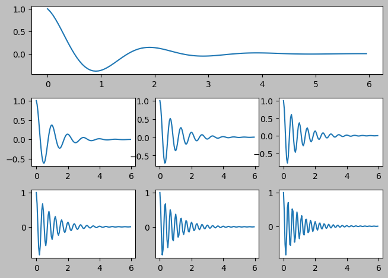

```python
fig = plt.figure(facecolor='0.75')
ax1 = fig.add_subplot(311)
ax2 = fig.add_subplot(334)
ax3 = fig.add_subplot(335)
ax4 = fig.add_subplot(336)
ax5 = fig.add_subplot(337)
ax6 = fig.add_subplot(338)
ax7 = fig.add_subplot(339)

print("type of fig =",type(fig))
print("type of ax1 =",type(ax1))

t = np.arange(0, 6.0, 0.05)
ax1.plot(t, np.exp(-t) * np.cos(1*np.pi*t))
ax2.plot(t, np.exp(-t) * np.cos(2*np.pi*t))
ax3.plot(t, np.exp(-t) * np.cos(3*np.pi*t))
ax4.plot(t, np.exp(-t) * np.cos(4*np.pi*t))
ax5.plot(t, np.exp(-t) * np.cos(5*np.pi*t))
ax6.plot(t, np.exp(-t) * np.cos(6*np.pi*t))
ax7.plot(t, np.exp(-t) * np.cos(7*np.pi*t))

plt.tight_layout()
plt.savefig("VisualizationPart01.zzz.png")
plt.show()
```

## **Description of the image shown above, VisualizationPart01.09.png**

### Type of Image

A composite figure containing seven subplots: one large subplot spanning the full width at the top, and six smaller subplots arranged in two rows and three columns beneath it. All plots display damped oscillatory curves.

### Overall Summary

The image demonstrates a “fancy arrangement” of subplots created by repeatedly calling the Figure object's add_subplot method with carefully chosen subplot numbers. The layout shows how add_subplot can be used to construct non‑rectangular or uneven subplot configurations, even though the underlying scheme can be difficult to design.

### Detailed Description

The figure contains seven total subplots:

- The top subplot spans the entire width of the figure and shows a single damped oscillatory curve that begins near 1, dips below zero, and oscillates with decreasing amplitude.
- Below it are six smaller subplots arranged in a 2×3 grid.
- Each of the six smaller plots displays a damped oscillation similar in shape but with increasing frequency from left to right and top to bottom.
- All plots share x‑axes ranging from approximately 0 to 6 and y‑axes ranging from about −1 to 1.
- The background of the figure is gray, while each subplot has a white plotting area.
- The arrangement visually reflects the use of add_subplot with specific plot numbers chosen to create a non‑uniform layout.

### Purpose of the Image

The image supports the discussion of “fancy arrangements” of subplots created using the add_subplot method. It illustrates how subplot numbers can be manipulated to produce complex layouts beyond simple rectangular grids. This prepares the reader for the introduction of subplot2grid, a more intuitive and flexible method for designing such arrangements.

##### Call the plt.subplot method

You can also create fancy arrangements of subplots like the one shown below by calling the **plt.subplot** method if you can figure out the scheme used in the following code. I also find it very difficult to use this scheme to design fancy arrangements. As mentioned earlier, there is another scheme that I will explain later that is just as powerful and easy to use. Therefore, I won't try to explain this scheme either.

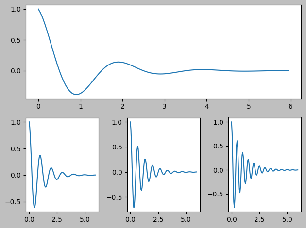

```python
fig = plt.figure(facecolor='0.75')

ax1 = plt.subplot(2,1,1)
ax2 = plt.subplot(2,3,4)
ax3 = plt.subplot(2,3,5)
ax4 = plt.subplot(2,3,6)

t = np.arange(0, 6.0, 0.05)
ax1.plot(t, np.exp(-t) * np.cos(1*np.pi*t))
ax2.plot(t, np.exp(-t) * np.cos(2*np.pi*t))
ax3.plot(t, np.exp(-t) * np.cos(3*np.pi*t))
ax4.plot(t, np.exp(-t) * np.cos(4*np.pi*t))

plt.tight_layout()
plt.savefig("VisualizationPart01.zzz.png")
plt.show()
```

## **Description of the image shown above, VisualizationPart01.10.png**

### Type of Image

A figure containing four subplots arranged in a non‑uniform layout: one large subplot spanning the full width of the top row, and three smaller subplots arranged in a single row beneath it. All plots display damped oscillatory curves.

### Overall Summary

The image demonstrates a fancy subplot arrangement created by repeatedly calling the plt.subplot method with carefully chosen subplot numbers. The layout shows how subplot numbering can be manipulated to produce non‑rectangular arrangements, even though the underlying scheme is difficult to design and interpret.

### Purpose of the Image

The image supports the explanation of how fancy subplot arrangements can be created using the plt.subplot method. It illustrates the complexity of designing such layouts manually and sets the stage for introducing subplot2grid as a more intuitive and flexible alternative for constructing non‑rectangular subplot configurations.

##### Call the plt.subplot2grid method

The following code calls the matplotlib.pyplot.subplot2grid method to create the fancy arrangement of subplots shown below.

The description of the method in the documentation reads as follows:

**subplot2grid(shape, loc, rowspan=1, colspan=1, ...)**

**Create a subplot in a grid. The grid is specified by shape, at location of loc, spanning rowspan, colspan cells in each direction. The index for loc is 0-based.**

Explanation:

The (3,3) argument means that the grid has three rows and three columns.

The combined (3,3),(0,0) arguments mean that the first subplot is positioned at location (0,0) in the grid (the upper-left corner).

The combined (3,3),(0,0),colspan=3 arguments mean that the first subplot extends across all three columns in the first row of the grid.

The combined (3,3),(1,0),colspan=2 arguments mean that the second subplot is located at the left end of the second row and extends across the first two columns.

The combined (3,3),(1, 2),rowspan=2) arguments mean that the third subplot is located at the right end of the second row,is one column wide, and extends downward into the third row.

The arguments for the fourth and fifth subplots simply place them in the first and second columns of the third row.

There is no error message if you create an overlapping subplot conflict with colspan or rowspan. The last of the competing subplots will prevail and the overlapped subplot will disappear.

```
type of fig = <class 'matplotlib.figure.Figure'>
type of ax1 = <class 'matplotlib.axes._axes.Axes'>
```

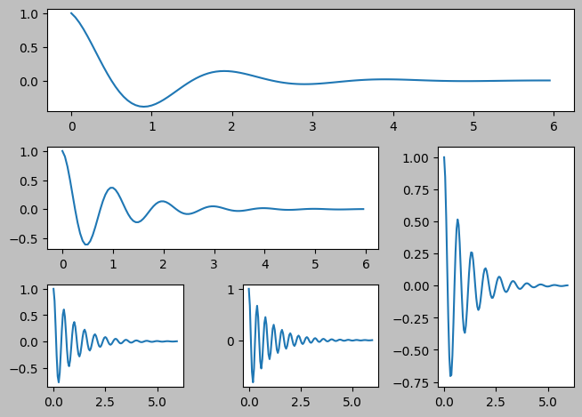

```python
fig = plt.figure(facecolor='0.75')

ax1 = plt.subplot2grid((3,3),(0,0),colspan=3)
ax2 = plt.subplot2grid((3,3),(1,0),colspan=2)
ax3 = plt.subplot2grid((3,3),(1, 2),rowspan=2)
ax4 = plt.subplot2grid((3,3),(2, 0))
ax5 = plt.subplot2grid((3,3),(2, 1))

print("type of fig =",type(fig))
print("type of ax1 =",type(ax1))

t = np.arange(0, 6.0, 0.05)
ax1.plot(t, np.exp(-t) * np.cos(1*np.pi*t))
ax2.plot(t, np.exp(-t) * np.cos(2*np.pi*t))
ax3.plot(t, np.exp(-t) * np.cos(3*np.pi*t))
ax4.plot(t, np.exp(-t) * np.cos(4*np.pi*t))
ax5.plot(t, np.exp(-t) * np.cos(5*np.pi*t))

plt.tight_layout()
plt.savefig("VisualizationPart01.zzz.png")
plt.show()
```

## **Description of the image shown above, VisualizationPart01.11.png**

### Type of Image

A figure containing five subplots arranged in a non‑uniform layout created using a 3×3 grid. The top subplot spans the entire width of the first row, the second subplot spans two columns in the second row, the third subplot occupies the rightmost column of both the second and third rows, and the remaining two subplots fill the left and middle cells of the bottom row. All plots display damped oscillatory curves.

### Overall Summary

The image demonstrates how the matplotlib.pyplot.subplot2grid method can be used to construct a fancy subplot arrangement by specifying grid shape, starting location, and optional rowspan and colspan values. Each subplot shows a damped oscillation with different frequencies, illustrating how subplot2grid allows flexible placement of axes within a defined grid.

### Detailed Description

The figure contains five total subplots arranged within a 3×3 grid:

- The top subplot spans all three columns of the first row and displays a damped oscillatory curve that begins near 1 and gradually approaches zero while oscillating.
- The second subplot occupies the left two columns of the second row and shows a similar damped oscillation with a higher frequency.
- The third subplot is positioned in the rightmost column of the second row and extends downward into the third row, showing an even higher‑frequency damped oscillation.
- The fourth and fifth subplots occupy the first and second columns of the third row, each displaying damped oscillations with progressively increasing frequencies.
- All plots share x‑axes ranging from approximately 0 to 6, and y‑axes ranging from about −1 to 1.
- The background of the figure is gray, while each subplot has a white plotting area.

### Purpose of the Image

The image supports the explanation of how to create complex subplot arrangements using the subplot2grid method. It visually demonstrates how shape, loc, rowspan, and colspan parameters determine subplot placement, and how this method provides a more intuitive and flexible alternative to constructing fancy arrangements with add_subplot or plt.subplot.

## Sharing axes

Sometimes when you arrange multiple subplots in a figure, it is cosmetically pleasing to let them share the tick labeling on the x-axis, the y-axis or both. This can be done by setting one or the other or both of the keyword parameters named **sharex** and **sharey** to **True** when you call **plt.subplots** to create the **Figure** object. This is illustrated by the following code.

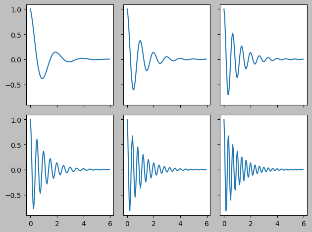

```python
fig,axes = plt.subplots(nrows=2,ncols=3,sharex=True,sharey=True)
#The above statement can also be written as follows:
#fig,axes = plt.subplots(2,3)
fig.set_facecolor('0.75')

t = np.arange(0, 6.0, 0.05)
axes[0,0].plot(t, np.exp(-t) * np.cos(1*np.pi*t))
axes[0,1].plot(t, np.exp(-t) * np.cos(2*np.pi*t))
axes[0,2].plot(t, np.exp(-t) * np.cos(3*np.pi*t))
axes[1,0].plot(t, np.exp(-t) * np.cos(4*np.pi*t))
axes[1,1].plot(t, np.exp(-t) * np.cos(5*np.pi*t))
axes[1,2].plot(t, np.exp(-t) * np.cos(6*np.pi*t))

plt.tight_layout()
plt.savefig("VisualizationPart01.zzz.png")
plt.show()
```

## **Description of the image shown above, VisualizationPart01.12.png**

### Type of Image

A figure containing six subplots arranged in a 2×3 grid. Each subplot displays a damped oscillatory curve with similar amplitude decay but increasing oscillation frequency from left to right and top to bottom.

### Overall Summary

The image illustrates the result of creating a 2×3 grid of subplots using plt.subplots with the sharex and sharey keyword parameters set to True. All subplots share the same x‑axis and y‑axis tick labeling, producing a uniform and visually consistent layout that emphasizes differences in oscillation frequency rather than differences in axis scaling.

### Detailed Description

The figure consists of six subplots arranged in two rows and three columns.

- Each subplot shows a curve that begins near 1, oscillates with decreasing amplitude, and gradually approaches zero.
- The oscillation frequency increases progressively across the grid.
- All subplots share identical x‑axis limits (approximately 0 to 6) and y‑axis limits (approximately −1 to 1).
- Because sharex=True and sharey=True were used, the tick labels on the axes are synchronized across all subplots.
- The background of the figure is gray, while each subplot has a white plotting area.
- The uniform axis scaling highlights the differences in waveform frequency rather than differences in axis ranges.

### Purpose of the Image

The image supports the explanation of how to share axes across multiple subplots using the sharex and sharey parameters in plt.subplots. It demonstrates how shared axes improve visual consistency, reduce redundant labeling, and make it easier to compare related plots within a multi‑panel figure.

## My preferences

### plt.subplots(nrows,ncols)

My preferred approach for creating arrangements with subplots on a uniform grid is to call the matplotlib.pyplot.subplots method to create a matplotlib.figure.Figure object with the desired rectangular shape.

### subplot2grid(shape,loc,rowspan,colspan,...)

My preferred approach for creating fancy arrangements where the individual subplots may be different sizes and may have different shapes is to call matplotlib.pyplot.subplot2grid to create the arrangement.

## Websites containing information on how to arrange subplots in a figure

The following is a non-exhaustive list of websites containing information on how to arrange subplots in a figure.

As a remindeder, this eBook is designed to serve as the only required resource for this course. However, you may find it helpful to explore additional materials that expand on the topics introduced here.

These external materials are offered strictly for optional enrichment. All required learning objectives for this course can be met using only the accessible materials provided within this eBook. You are not expected to visit any external site in order to complete assignments or demonstrate mastery of the course content.

Because these supplemental resources are hosted by third parties, their availability may change without notice, and they have not been evaluated for accessibility compliance. If you choose to explore them, please be aware that they may not meet current accessibility standards.

- [Matplotlib tutorial](http://www.labri.fr/perso/nrougier/teaching/matplotlib/) by Nicolas P. Rougier
- [Matplotlib Tutorial: Multiple Plots and Double Axes](https://www.python-course.eu/matplotlib_multiple_figures.php)
- [Advanced plotting](https://python4astronomers.github.io/plotting/advanced.html)
- [Graphing in Python with Matplotlib - subplots video](https://cosmolearning.org/video-lectures/subplots/)
- [Subplots in matplotlib](https://plot.ly/matplotlib/subplots/)
- [subplots_demo](https://matplotlib.org/examples/pylab_examples/subplots_demo.html)
- [Pyplot tutorial](http://matplotlib.org/users/pyplot_tutorial.html)
- [Plotting in Python with matplotlib](https://chryswoods.github.io/2013-11-14-exeter/lessons/thw-matplotlib/tutorial.html)
- [Plotting with matplotlib video](https://www.youtube.com/watch?v=P7SVi0YTIuE)
- [Tight Layout guide](https://matplotlib.org/users/tight_layout_guide.html)

#### --To be continued in the tutorial titled Visualization Exercises Part 2--

Author: Prof. Richard G. Baldwin, Austin Community College, Austin, TX

File: VisualizationPart01.ipynb

Revised:03/12/26

Copyright 2018 Richard G. Baldwin

-end-